# Employee-Performance-Analysis

# Feature Selection

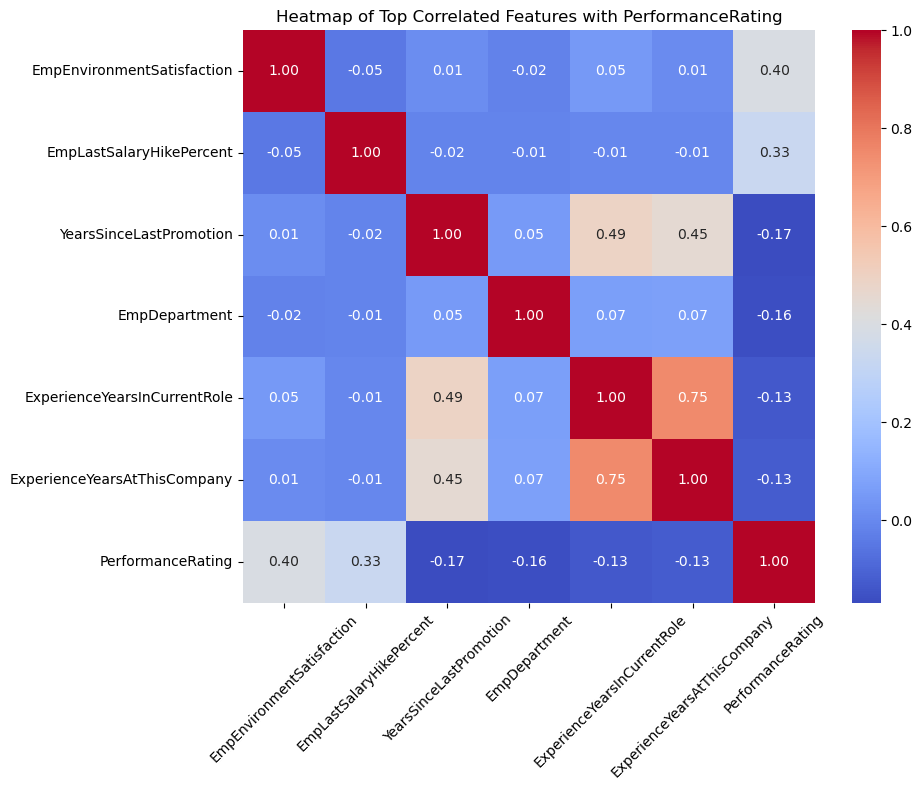

```python
# Drop non-numeric or irrelevant columns (like 'EmpNumber')
df_numeric = df.drop(columns=['EmpNumber'])

# Compute full correlation matrix
corr_matrix = df_numeric.corr()

# Get correlations with PerformanceRating, sort them
target_corr = corr_matrix['PerformanceRating'].drop('PerformanceRating')
top_features = target_corr.abs().sort_values(ascending=False).head(6).index  # top 6 most correlated features

# Include 'PerformanceRating' itself in the filtered list
top_corr_features = list(top_features) + ['PerformanceRating']

# Create a smaller correlation matrix with only top features
filtered_corr = df_numeric[top_corr_features].corr()

# Plot the heatmap
plt.figure(figsize=(10, 8))
sns.heatmap(filtered_corr, annot=True, cmap='coolwarm', fmt=".2f", square=True)
plt.title('Heatmap of Top Correlated Features with PerformanceRating')
plt.xticks(rotation=45)
plt.yticks(rotation=0)
plt.tight_layout()
plt.show()
```

### INSIGHTS:

1. **Work Environment Has a Clear Impact**
- EmpEnvironmentSatisfaction has the highest positive correlation with PerformanceRating.
- Action: Improve workplace conditions, team dynamics, and management support.
2. **Recognition Through Pay Hikes Helps**
- A salary hike (EmpLastSalaryHikePercent) is clearly associated with better performance.
- Action: Ensure fair, timely raises for deserving employees. Reward good performance visibly.
3. **Stagnation Reduces Performance**
- Both YearsSinceLastPromotion and ExperienceYearsInCurrentRole have negative correlations.
- Action: Identify employees who have been in the same role or without promotion for long — they might be at risk of disengagement.
4. **Departmental Variation Matters**
- Different departments may exhibit different performance trends.
- Action: Drill down by department to identify training or process gaps.
5. **Long Tenure ≠ High Performance**
- Contrary to common assumptions, longer tenure (ExperienceYearsAtThisCompany) shows a slight drop in performance.
- Action: Provide career development opportunities and role variety for long-time employees.

**Conclusion**

The most actionable levers to improve performance at INX Future Inc. are:

- Enhancing employee satisfaction (especially environment-related)
- Fair and timely compensation
- Career progression paths
- Department-level performance audits

# Model Creation

### Logistic Regression

```python
from sklearn.linear_model import LogisticRegression
LR=LogisticRegression()
LR.fit(x_train_smote,y_train_smote)
```

```
LogisticRegression()
```

```python
y_train_predict=LR.predict(x_train_smote)
y_train_predict
```

```
array([2, 3, 2, ..., 4, 4, 4], dtype=int64)
```

```python
from sklearn.metrics import confusion_matrix,classification_report,accuracy_score,recall_score,precision_score,f1_score
```

```python
print(confusion_matrix(y_train_smote,y_train_predict))
```

```
[[572  87  31]
 [ 88 520  82]
 [ 38  61 591]]
```

```python
print(classification_report(y_train_smote,y_train_predict))
```

```
              precision    recall  f1-score   support

           2       0.82      0.83      0.82       690
           3       0.78      0.75      0.77       690
           4       0.84      0.86      0.85       690

    accuracy                           0.81      2070
   macro avg       0.81      0.81      0.81      2070
weighted avg       0.81      0.81      0.81      2070
```

```python
y_test_predict=LR.predict(x_test)
y_test_predict
```

```
array([2, 2, 3, 3, 3, 3, 3, 3, 2, 4, 4, 4, 3, 2, 3, 4, 3, 3, 4, 4, 2, 3,
       4, 3, 4, 4, 3, 3, 3, 3, 3, 3, 3, 2, 2, 3, 2, 3, 3, 3, 2, 3, 4, 3,
       3, 3, 3, 2, 2, 2, 2, 2, 3, 3, 2, 3, 3, 3, 3, 2, 2, 3, 4, 3, 3, 2,
       2, 4, 3, 3, 2, 3, 4, 4, 3, 3, 3, 3, 3, 4, 3, 3, 3, 4, 4, 3, 2, 3,
       3, 2, 3, 3, 3, 3, 3, 2, 2, 3, 4, 3, 3, 2, 3, 3, 3, 4, 3, 4, 3, 2,
       3, 2, 3, 3, 4, 3, 3, 3, 3, 3, 3, 3, 3, 3, 3, 3, 4, 3, 3, 3, 3, 2,
       3, 3, 3, 3, 3, 3, 3, 2, 3, 4, 3, 3, 3, 3, 3, 3, 3, 3, 2, 3, 2, 4,
       3, 2, 3, 4, 2, 3, 3, 3, 2, 4, 3, 4, 3, 2, 3, 4, 3, 3, 3, 2, 3, 3,
       2, 3, 3, 3, 3, 3, 2, 3, 3, 2, 3, 2, 3, 3, 3, 2, 3, 4, 2, 3, 3, 3,
       4, 4, 3, 3, 2, 3, 3, 4, 3, 3, 3, 3, 3, 3, 3, 3, 3, 2, 3, 3, 3, 3,
       3, 3, 3, 3, 4, 4, 3, 4, 3, 2, 3, 3, 3, 4, 4, 2, 3, 3, 4, 3],
      dtype=int64)
```

```python
print(confusion_matrix(y_test,y_test_predict))
```

```
[[ 19   7   3]
 [ 27 140  17]
 [  0   9  18]]
```

```python
accuracy_LR=accuracy_score(y_test,y_test_predict)
recall_LR=recall_score(y_test,y_test_predict,average='weighted')
precision_LR=precision_score(y_test,y_test_predict,average='weighted')
f1_score_LR=f1_score(y_test,y_test_predict,average='weighted')

print(accuracy_LR)
print(recall_LR)
print(precision_LR)
print(f1_score_LR)
```

```
0.7375
0.7375
0.7912330820082537
0.7549024635495223
```

```python
print(classification_report(y_test,y_test_predict))
```

```
              precision    recall  f1-score   support

           2       0.41      0.66      0.51        29
           3       0.90      0.76      0.82       184
           4       0.47      0.67      0.55        27

    accuracy                           0.74       240
   macro avg       0.59      0.69      0.63       240
weighted avg       0.79      0.74      0.75       240
```

### K Nearest Neighbor (KNN)

```python
from sklearn.neighbors import KNeighborsClassifier
```

```python
# Finding optimal value for k to determine how many nearest neighbors to find
```

```python
error_rate=[]
for i in range (1,11):
    knn=KNeighborsClassifier(n_neighbors=i)
    knn.fit(x_train_smote,y_train_smote)
    y_pred_i=knn.predict(x_test)
    error_rate.append(np.mean(y_pred_i!=y_test))

error_rate
```

```
[0.3875,
 0.425,
 0.4125,
 0.43333333333333335,
 0.42083333333333334,
 0.4625,
 0.425,
 0.4625,
 0.45,
 0.45416666666666666]
```

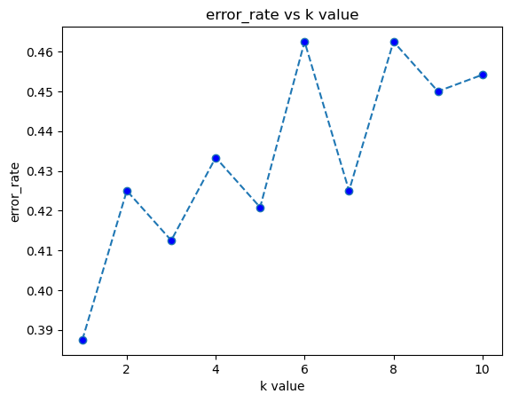

```python
# Let's plot k value and error rate
plt.plot(range(1,11),error_rate,linestyle='dashed',marker='o',markerfacecolor='blue')
plt.title('error_rate vs k value')
plt.xlabel('k value')
plt.ylabel('error_rate')
plt.show()
```

```python
# Let's fit the data into KNN model
KNN=KNeighborsClassifier(n_neighbors=7)
KNN.fit(x_train_smote,y_train_smote)
```

```
KNeighborsClassifier(n_neighbors=7)
```

```python
y_train_predict=KNN.predict(x_train_smote)
y_train_predict
```

```
array([2, 3, 3, ..., 4, 4, 4], dtype=int64)
```

```python
print(confusion_matrix(y_train_smote,y_train_predict))
```

```
[[679   9   2]
 [156 447  87]
 [  2   3 685]]
```

```python
print(classification_report(y_train_smote,y_train_predict))
```

```
              precision    recall  f1-score   support

           2       0.81      0.98      0.89       690
           3       0.97      0.65      0.78       690
           4       0.89      0.99      0.94       690

    accuracy                           0.87      2070
   macro avg       0.89      0.87      0.87      2070
weighted avg       0.89      0.87      0.87      2070
```

```python
y_test_predict=KNN.predict(x_test)
y_test_predict
```

```
array([4, 2, 3, 2, 2, 2, 2, 3, 3, 4, 4, 4, 3, 3, 3, 3, 3, 4, 4, 2, 3, 4,
       3, 3, 3, 4, 2, 3, 3, 3, 2, 3, 3, 3, 2, 3, 4, 3, 2, 3, 3, 4, 4, 3,
       3, 2, 3, 3, 2, 3, 2, 2, 2, 3, 2, 4, 3, 3, 3, 2, 4, 4, 3, 4, 3, 4,
       2, 4, 2, 3, 3, 3, 4, 4, 3, 2, 3, 3, 4, 3, 3, 3, 3, 4, 4, 3, 3, 3,
       3, 2, 2, 4, 2, 3, 3, 2, 2, 3, 3, 3, 2, 2, 3, 3, 3, 4, 3, 4, 3, 2,
       3, 2, 3, 3, 4, 4, 2, 3, 3, 2, 2, 3, 3, 3, 3, 2, 2, 3, 3, 2, 2, 3,
       3, 3, 4, 4, 4, 3, 2, 4, 3, 4, 3, 4, 3, 2, 2, 3, 2, 2, 3, 2, 2, 2,
       3, 3, 3, 4, 2, 4, 2, 3, 3, 3, 3, 4, 3, 2, 3, 4, 2, 2, 3, 2, 2, 4,
       3, 3, 3, 3, 4, 2, 3, 3, 3, 3, 3, 4, 3, 3, 2, 2, 2, 4, 3, 3, 3, 3,
       4, 4, 4, 2, 2, 2, 3, 2, 3, 2, 3, 4, 4, 3, 3, 2, 3, 2, 3, 3, 3, 3,
       3, 3, 3, 2, 4, 3, 4, 4, 3, 2, 3, 4, 2, 4, 4, 4, 3, 3, 4, 3],
      dtype=int64)
```

```python
print(confusion_matrix(y_test,y_test_predict))
```

```
[[ 14  12   3]
 [ 49 104  31]
 [  2   5  20]]
```

```python
accuracy_KNN=accuracy_score(y_test,y_test_predict)
recall_KNN=recall_score(y_test,y_test_predict,average='weighted')
precision_KNN=precision_score(y_test,y_test_predict,average='weighted')
f1_score_KNN=f1_score(y_test,y_test_predict,average='weighted')

print(accuracy_KNN)
print(recall_KNN)
print(precision_KNN)
print(f1_score_KNN)
```

```
0.575
0.575
0.7266454757363848
0.6143899934116188
```

```python
print(classification_report(y_test,y_test_predict))
```

```
              precision    recall  f1-score   support

           2       0.22      0.48      0.30        29
           3       0.86      0.57      0.68       184
           4       0.37      0.74      0.49        27

    accuracy                           0.57       240
   macro avg       0.48      0.60      0.49       240
weighted avg       0.73      0.57      0.61       240
```

### Support Vector Machine (SVM)

```python
from sklearn.svm import SVC
SVC=SVC()
SVC.fit(x_train_smote,y_train_smote)
```

```
SVC()
```

```python
y_train_predict=SVC.predict(x_train_smote)
y_train_predict
```

```
array([2, 4, 2, ..., 4, 4, 4], dtype=int64)
```

```python
print(confusion_matrix(y_train_smote,y_train_predict))
```

```
[[522  69  99]
 [147 418 125]
 [ 27  35 628]]
```

```python
print(classification_report(y_train_smote,y_train_predict))
```

```
              precision    recall  f1-score   support

           2       0.75      0.76      0.75       690
           3       0.80      0.61      0.69       690
           4       0.74      0.91      0.81       690

    accuracy                           0.76      2070
   macro avg       0.76      0.76      0.75      2070
weighted avg       0.76      0.76      0.75      2070
```

```python
y_test_predict=SVC.predict(x_test)
y_test_predict
```

```
array([4, 2, 3, 3, 3, 3, 2, 3, 3, 4, 3, 4, 3, 3, 2, 4, 3, 2, 4, 4, 2, 4,
       3, 3, 4, 4, 3, 3, 3, 4, 2, 4, 3, 4, 4, 2, 4, 3, 3, 3, 2, 4, 4, 2,
       3, 3, 3, 3, 2, 2, 2, 4, 2, 3, 2, 4, 2, 3, 2, 2, 4, 4, 4, 4, 3, 4,
       2, 4, 2, 3, 2, 2, 4, 4, 3, 4, 3, 3, 3, 3, 3, 3, 2, 4, 4, 2, 2, 3,
       3, 4, 2, 4, 3, 3, 2, 2, 2, 3, 3, 3, 3, 2, 3, 3, 4, 4, 3, 4, 3, 4,
       3, 2, 3, 2, 4, 4, 3, 2, 2, 2, 3, 3, 3, 3, 3, 3, 4, 3, 2, 3, 2, 2,
       3, 2, 3, 3, 4, 2, 3, 4, 3, 4, 2, 4, 3, 3, 2, 3, 3, 3, 2, 3, 2, 4,
       3, 2, 3, 4, 2, 4, 2, 3, 2, 3, 2, 4, 4, 4, 3, 4, 4, 2, 3, 2, 3, 2,
       2, 4, 3, 3, 4, 3, 4, 3, 3, 2, 3, 3, 3, 3, 3, 2, 3, 4, 2, 3, 3, 3,
       4, 4, 4, 2, 2, 3, 3, 3, 3, 3, 3, 4, 3, 3, 3, 3, 3, 2, 3, 3, 2, 3,
       3, 3, 3, 3, 4, 4, 2, 4, 3, 2, 3, 4, 3, 4, 4, 4, 3, 3, 4, 2],
      dtype=int64)
```

```python
print(confusion_matrix(y_test,y_test_predict))
```

```
[[ 14   4  11]
 [ 45 105  34]
 [  3   3  21]]
```

```python
accuracy_SVM=accuracy_score(y_test,y_test_predict)
recall_SVM=recall_score(y_test,y_test_predict,average='weighted')
precision_SVM=precision_score(y_test,y_test_predict,average='weighted')
f1_score_SVM=f1_score(y_test,y_test_predict,average='weighted')

print(accuracy_SVM)
print(recall_SVM)
print(precision_SVM)
print(f1_score_SVM)
```

```
0.5833333333333334
0.5833333333333334
0.7818304007820137
0.6319048577113093
```

```python
print(classification_report(y_test,y_test_predict))
```

```
              precision    recall  f1-score   support

           2       0.23      0.48      0.31        29
           3       0.94      0.57      0.71       184
           4       0.32      0.78      0.45        27

    accuracy                           0.58       240
   macro avg       0.49      0.61      0.49       240
weighted avg       0.78      0.58      0.63       240
```

### Decision Tree

```python
from sklearn.tree import DecisionTreeClassifier
DTC=DecisionTreeClassifier()
DTC.fit(x_train_smote,y_train_smote)
```

```
DecisionTreeClassifier()
```

```python
y_train_predict=DTC.predict(x_train_smote)
y_train_predict
```

```
array([2, 3, 3, ..., 4, 4, 4], dtype=int64)
```

```python
print(confusion_matrix(y_train_smote,y_train_predict))
```

```
[[690   0   0]
 [  0 690   0]
 [  0   0 690]]
```

```python
print(classification_report(y_train_smote,y_train_predict))
```

```
              precision    recall  f1-score   support

           2       1.00      1.00      1.00       690
           3       1.00      1.00      1.00       690
           4       1.00      1.00      1.00       690

    accuracy                           1.00      2070
   macro avg       1.00      1.00      1.00      2070
weighted avg       1.00      1.00      1.00      2070
```

```python
y_test_predict=DTC.predict(x_test)
y_test_predict
```

```
array([4, 2, 3, 3, 3, 3, 3, 3, 2, 3, 3, 4, 3, 4, 2, 2, 3, 3, 4, 2, 2, 4,
       3, 3, 3, 4, 3, 3, 3, 3, 3, 3, 3, 3, 3, 3, 3, 3, 3, 3, 2, 3, 4, 3,
       3, 3, 3, 3, 4, 3, 2, 2, 3, 3, 3, 3, 3, 2, 3, 2, 2, 3, 3, 3, 3, 3,
       3, 4, 3, 3, 3, 3, 4, 4, 3, 2, 3, 3, 3, 3, 3, 3, 3, 3, 4, 3, 3, 3,
       3, 4, 3, 3, 3, 3, 3, 3, 3, 3, 3, 3, 3, 3, 3, 3, 4, 4, 3, 3, 3, 2,
       3, 2, 3, 3, 3, 3, 3, 3, 3, 2, 3, 3, 3, 3, 3, 3, 3, 3, 3, 3, 2, 4,
       3, 3, 3, 3, 4, 3, 3, 2, 3, 4, 3, 3, 3, 3, 3, 3, 3, 3, 3, 3, 2, 3,
       3, 4, 3, 4, 3, 4, 3, 3, 2, 3, 3, 4, 3, 3, 3, 4, 3, 3, 3, 3, 3, 3,
       2, 3, 3, 3, 3, 3, 2, 3, 3, 2, 3, 2, 3, 3, 3, 3, 3, 4, 2, 3, 3, 3,
       3, 3, 3, 3, 3, 3, 3, 3, 3, 3, 3, 3, 3, 3, 3, 3, 3, 3, 4, 3, 3, 3,
       3, 3, 3, 3, 4, 4, 3, 3, 3, 2, 3, 3, 3, 3, 3, 3, 3, 2, 3, 3],
      dtype=int64)
```

```python
print(confusion_matrix(y_test,y_test_predict))
```

```
[[ 21   7   1]
 [  6 171   7]
 [  0   8  19]]
```

```python
accuracy_DT=accuracy_score(y_test,y_test_predict)
recall_DT=recall_score(y_test,y_test_predict,average='weighted')
precision_DT=precision_score(y_test,y_test_predict,average='weighted')
f1_score_DT=f1_score(y_test,y_test_predict,average='weighted')

print(accuracy_DT)
print(recall_DT)
print(precision_DT)
print(f1_score_DT)
```

```
0.8791666666666667
0.8791666666666667
0.8779868578255675
0.8784403153153153
```

```python
print(classification_report(y_test,y_test_predict))
```

```
              precision    recall  f1-score   support

           2       0.78      0.72      0.75        29
           3       0.92      0.93      0.92       184
           4       0.70      0.70      0.70        27

    accuracy                           0.88       240
   macro avg       0.80      0.79      0.79       240
weighted avg       0.88      0.88      0.88       240
```

### Random Forest

```python
from sklearn.ensemble import RandomForestClassifier
RFC=RandomForestClassifier()
RFC.fit(x_train_smote,y_train_smote)
```

```
RandomForestClassifier()
```

```python
y_train_predict=RFC.predict(x_train_smote)
y_train_predict
```

```
array([2, 3, 3, ..., 4, 4, 4], dtype=int64)
```

```python
print(confusion_matrix(y_train_smote,y_train_predict))
```

```
[[690   0   0]
 [  0 690   0]
 [  0   0 690]]
```

```python
print(classification_report(y_train_smote,y_train_predict))
```

```
              precision    recall  f1-score   support

           2       1.00      1.00      1.00       690
           3       1.00      1.00      1.00       690
           4       1.00      1.00      1.00       690

    accuracy                           1.00      2070
   macro avg       1.00      1.00      1.00      2070
weighted avg       1.00      1.00      1.00      2070
```

```python
y_test_predict=RFC.predict(x_test)
y_test_predict
```

```
array([3, 2, 3, 3, 3, 3, 3, 3, 2, 3, 3, 4, 3, 3, 2, 4, 3, 3, 4, 2, 2, 3,
       3, 3, 3, 4, 3, 3, 3, 3, 3, 3, 3, 3, 4, 3, 2, 3, 3, 3, 2, 3, 4, 3,
       3, 3, 3, 3, 3, 3, 2, 2, 3, 3, 3, 3, 3, 3, 3, 2, 4, 3, 3, 3, 3, 3,
       3, 4, 3, 2, 2, 3, 4, 4, 3, 2, 3, 3, 3, 3, 3, 3, 3, 3, 4, 3, 3, 3,
       3, 2, 3, 3, 3, 3, 3, 3, 3, 3, 3, 3, 3, 3, 3, 3, 4, 4, 3, 3, 3, 2,
       3, 2, 3, 3, 3, 3, 3, 3, 3, 3, 3, 3, 3, 3, 3, 3, 3, 3, 3, 3, 2, 3,
       3, 3, 3, 3, 4, 3, 3, 3, 3, 4, 3, 3, 3, 3, 3, 3, 3, 3, 3, 3, 2, 2,
       3, 3, 3, 4, 3, 4, 3, 3, 2, 3, 3, 4, 3, 2, 3, 4, 3, 3, 3, 3, 3, 3,
       2, 3, 3, 3, 3, 3, 2, 3, 3, 3, 3, 3, 3, 3, 3, 3, 3, 3, 2, 3, 3, 3,
       4, 3, 3, 3, 3, 3, 3, 3, 3, 3, 3, 3, 3, 3, 3, 3, 3, 3, 3, 3, 3, 3,
       3, 3, 3, 3, 4, 4, 3, 3, 3, 2, 3, 3, 3, 4, 4, 3, 3, 2, 3, 3],
      dtype=int64)
```

```python
print(confusion_matrix(y_test,y_test_predict))
```

```
[[ 24   3   2]
 [  2 179   3]
 [  0   8  19]]
```

```python
accuracy_RF=accuracy_score(y_test,y_test_predict)
recall_RF=recall_score(y_test,y_test_predict,average='weighted')
precision_RF=precision_score(y_test,y_test_predict,average='weighted')
f1_score_RF=f1_score(y_test,y_test_predict,average='weighted')

print(accuracy_RF)
print(recall_RF)
print(precision_RF)
print(f1_score_RF)
```

```
0.925
0.925
0.9228816632928475
0.9231461675579323
```

```python
print(classification_report(y_test,y_test_predict))
```

```
              precision    recall  f1-score   support

           2       0.92      0.83      0.87        29
           3       0.94      0.97      0.96       184
           4       0.79      0.70      0.75        27

    accuracy                           0.93       240
   macro avg       0.89      0.83      0.86       240
weighted avg       0.92      0.93      0.92       240
```

### Gradient Boosting

```python
from sklearn.ensemble import GradientBoostingClassifier
GBC=GradientBoostingClassifier()
GBC.fit(x_train_smote,y_train_smote)
```

```
GradientBoostingClassifier()
```

```python
y_train_predict=GBC.predict(x_train_smote)
y_train_predict
```

```
array([2, 3, 3, ..., 4, 4, 4], dtype=int64)
```

```python
print(confusion_matrix(y_train_smote,y_train_predict))
```

```
[[689   1   0]
 [  9 680   1]
 [  4   4 682]]
```

```python
print(classification_report(y_train_smote,y_train_predict))
```

```
              precision    recall  f1-score   support

           2       0.98      1.00      0.99       690
           3       0.99      0.99      0.99       690
           4       1.00      0.99      0.99       690

    accuracy                           0.99      2070
   macro avg       0.99      0.99      0.99      2070
weighted avg       0.99      0.99      0.99      2070
```

```python
y_test_predict=GBC.predict(x_test)
y_test_predict
```

```
array([2, 2, 3, 3, 3, 3, 3, 3, 2, 3, 3, 4, 3, 2, 2, 2, 3, 3, 4, 2, 2, 3,
       3, 3, 3, 4, 3, 3, 3, 3, 3, 3, 3, 3, 4, 3, 2, 3, 3, 3, 2, 3, 4, 3,
       3, 3, 3, 3, 3, 3, 2, 2, 3, 3, 3, 3, 3, 3, 3, 2, 2, 3, 3, 3, 3, 2,
       3, 4, 3, 2, 2, 3, 4, 4, 3, 2, 3, 3, 3, 4, 3, 3, 3, 3, 4, 3, 3, 3,
       3, 2, 3, 3, 3, 3, 3, 3, 3, 3, 3, 3, 3, 3, 3, 3, 4, 4, 3, 3, 3, 2,
       3, 2, 3, 3, 3, 3, 3, 3, 3, 3, 3, 3, 3, 3, 3, 3, 3, 3, 3, 3, 2, 3,
       3, 3, 3, 3, 4, 3, 3, 3, 3, 4, 3, 3, 3, 3, 3, 3, 3, 3, 3, 3, 2, 2,
       3, 3, 3, 4, 3, 4, 3, 3, 2, 3, 3, 4, 3, 3, 3, 4, 3, 3, 3, 3, 3, 3,
       2, 3, 3, 3, 3, 3, 2, 3, 3, 3, 3, 3, 3, 3, 3, 3, 3, 4, 2, 3, 3, 3,
       3, 3, 3, 3, 3, 3, 3, 3, 3, 3, 3, 3, 3, 3, 3, 3, 3, 3, 3, 3, 3, 3,
       3, 2, 3, 3, 4, 4, 3, 3, 3, 2, 3, 3, 3, 4, 4, 3, 3, 2, 3, 3],
      dtype=int64)
```

```python
print(confusion_matrix(y_test,y_test_predict))
```

```
[[ 26   3   0]
 [  5 176   3]
 [  0   7  20]]
```

```python
accuracy_GB=accuracy_score(y_test,y_test_predict)
recall_GB=recall_score(y_test,y_test_predict,average='weighted')
precision_GB=precision_score(y_test,y_test_predict,average='weighted')
f1_score_GB=f1_score(y_test,y_test_predict,average='weighted')

print(accuracy_GB)
print(recall_GB)
print(precision_GB)
print(f1_score_GB)
```

```
0.925
0.925
0.9246182016518623
0.9240915915915916
```

```python
print(classification_report(y_test,y_test_predict))
```

```
              precision    recall  f1-score   support

           2       0.84      0.90      0.87        29
           3       0.95      0.96      0.95       184
           4       0.87      0.74      0.80        27

    accuracy                           0.93       240
   macro avg       0.88      0.86      0.87       240
weighted avg       0.92      0.93      0.92       240
```

```python
!pip install tabulate
```

```python
from tabulate import tabulate

data=[['Logistic Regression',accuracy_LR,recall_LR,precision_LR,f1_score_LR],
      ['KNN',accuracy_KNN,recall_KNN,precision_KNN,f1_score_KNN],
      ['SVM',accuracy_SVM,recall_SVM,precision_SVM,f1_score_SVM],
      ['Decision Tree',accuracy_DT,recall_DT,precision_DT,f1_score_DT],
      ['Random Forest',accuracy_RF,recall_RF,precision_RF,f1_score_RF],
      ['Gradient Boosting',accuracy_GB,recall_GB,precision_GB,f1_score_GB]]

column_names=['Algorithms','Accuracy','Recall','Precision','f1 Score']

print(tabulate(data, headers = column_names, tablefmt = "fancy_grid"))
```

```
╒═════════════════════╤════════════╤══════════╤═════════════╤════════════╕
│ Algorithms          │   Accuracy │   Recall │   Precision │   f1 Score │
╞═════════════════════╪════════════╪══════════╪═════════════╪════════════╡
│ Logistic Regression │   0.7375   │ 0.7375   │    0.791233 │   0.754902 │
├─────────────────────┼────────────┼──────────┼─────────────┼────────────┤
│ KNN                 │   0.575    │ 0.575    │    0.726645 │   0.61439  │
├─────────────────────┼────────────┼──────────┼─────────────┼────────────┤
│ SVM                 │   0.583333 │ 0.583333 │    0.78183  │   0.631905 │
├─────────────────────┼────────────┼──────────┼─────────────┼────────────┤
│ Decision Tree       │   0.879167 │ 0.879167 │    0.877987 │   0.87844  │
├─────────────────────┼────────────┼──────────┼─────────────┼────────────┤
│ Random Forest       │   0.925    │ 0.925    │    0.922882 │   0.923146 │
├─────────────────────┼────────────┼──────────┼─────────────┼────────────┤
│ Gradient Boosting   │   0.925    │ 0.925    │    0.924618 │   0.924092 │
╘═════════════════════╧════════════╧══════════╧═════════════╧════════════╛
```

# Summary

### Strategic Recommendations

1. Boost Work Environment & Recognition
- Higher satisfaction and timely salary hikes are tied to better performance.
- Improve work-life balance and implement fair appraisal systems.
2. Encourage Growth & Promotions
- Long stagnation in the same role or no promotion → linked to reduced performance.
- Create internal mobility and growth programs.
3. Data-Driven HR Practices
- Deploy the trained model in the recruitment pipeline to predict likely top performers.
- Continuously monitor performance indicators for early intervention.

# Conclusion

The data science solution effectively identifies performance patterns and enables INX Future Inc. to:

- Predict employee performance with 93% accuracy,
- Improve retention of high performers,
- Make informed talent decisions,
- Preserve its reputation as a top employer.